# isoslides demo

September 21, 2016

## Use one hash (#) to create a section

## Use two hashes (##) to set a frame's header

## Section 1 Slide with Bullets

- Use attribute {.build} to indicate that their content should be displayed incrementally.
- Slide attributes can be combined if you need to specify more than one
- For example, ## Getting up {.smaller .build}

- The output will be smaller if we add {.smaller} on the frame header

## Section 1 Slide with Plot

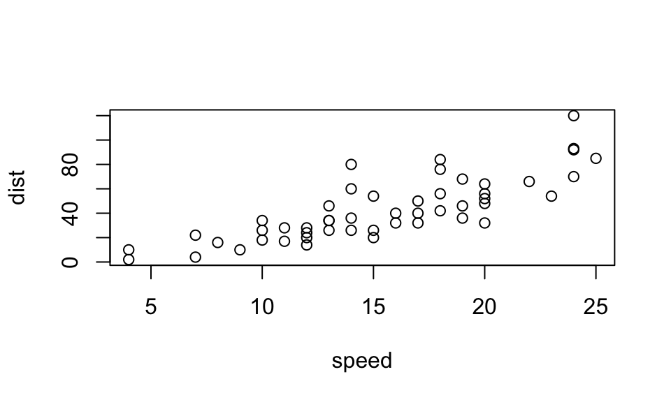

## In the morning

## Getting up

### What I like to do first thing

- Add a subtitle to a slide or section by including text after the pipe (|) character
- For example, Getting up | What I like to do first thing
- use four hyphens (- - - -) to create a new frame without a header
- add picture using

[figure not shown]

- picture of SOE

  ```markdown
  ![caption](path)
  ```

## Display Modes

- 'f' enable fullscreen mode
- 'w' toggle widescreen mode
- 'o' enable overview mode
- 'h' enable code highlight mode
- 'p' show presenter notes

## Going to sleep

- target specific slides or classes of slice with custom CSS by adding ids or classes to the slides headers within your document
- For example, Going to sleep {#nextsteps .emphasized} (see ioslides_style.css)
- Need to use css option in YAML: css: styles.css

## Code highlighting

```r
x <- 10
y <- x * 2
z <- 1 + 3
yy <- exp(4) + log(10)
```

## Code - HTML

```html
<div class="notes">
This is my *note*.

- It can contain markdown
- like this list

</div>
```

## Code - CSS

```css
#nextsteps {
   color: blue;
}

.emphasized {
   font-size: 1.2em;
}
```

## Code - R

```r
# load("data/salary.RData")
data(salary, package="DSC2014Tutorial")
knitr::opts_chunk$set(warning = FALSE,
                      echo = FALSE,
                      message = FALSE)
```

## Code - Markdown

```markdown
A friend once said:

> It's always better to give
> than to receive.
```

```markdown
---
output:
  ioslides_presentation:
    incremental: true
---
```

## Tables

```markdown
First Header  | Second Header
------------- | -------------
Content Cell  | Content Cell
Content Cell  | Content Cell
```

| First Header | Second Header |
| --- | --- |
| Content Cell | Content Cell |
| Content Cell | Content Cell |

## Font color

- Roses are red,
- violets are blue.

## Add logo

- use option logo: logo.png
- the rectangular element containing it can be customised with CSS
- See .gdbar img and .gdbar in ioslides_style.css file

## Layout

- use {.flexbox .vcenter} attributes to center content on a slide

## Layout 2

- horizontally center content by enclosing it in a div tag with class centered
- This text is centered.

## Layout 3

- two-column layout using the columns-2 class.

[figure not shown]

- Bullet 1
- Bullet 2
- Bullet 3

## Text Color

- color content using base color classes red, blue, green, yellow, and gray (or variations of them e.g. red2, red3, blue2, blue3, etc.)
- This text is red

## Presenter mode

## Math Equations

- \(y = \beta_1x + \beta_0\)

## Includes

- include content in the document header or before/after the document body
- includes:
  - in_header: header.html
  - before_body: doc_prefix.html
  - after_body: doc_suffix.html

## Share Options

- include a file named _output.yaml within the directory
- no YAML delimeters or enclosing output object are used in this file
- _output.yaml
  - ioslides_presentation:
  - widescreen: true
  - smaller: true